# Reproducible Research - Peer Assessment 2

Analysis Report of Impact by Weather Events based on NOAA Storm Databases

Miguel Luis Catalino

August 9, 2015

## Synopsis

This report show the damage in health and economic induced by weather events using data from 1950 to 2011 in the United State; using the NOAA database that contain the information about the every type of events occurred in every state and the number of fatalities and injuries, also the number of damage in the crops and properties.

## Data Processing

This area contain the data processing.

### Libraries

I’m using R.util for use the function bunzip2 to unzip the data.

```r
library(R.utils)
```

### Basic Settings

First, We get sure that the file exist, otherwise It’s downloaded and unzip it.

```r
options(scipen = 1)
filename = "data.csv.bz2"
url = "http://d396qusza40orc.cloudfront.net/repdata%2Fdata%2FStormData.csv.bz2"
list_dir <- dir(".")
if (!"Data.csv.bz2" %in% list_dir) {
download.file(url, destfile = filename)
}
if (!"data.csv" %in% list_dir) {
bunzip2(filename, overwrite = T, remove = F)
}
data <- read.csv("data.csv")
data.dim<-dim(data)
```

The number the raw data is 902297 and the number of columns is 37

I summarize the data with only the fatalities, injuries, properties damage (PROPDMG), crop damage (CROPDMG), states and types of events (EVTYPE). Also I add the Count column to summarize the number of event that occurred.

```r
data$Count <- 1
newdata <- aggregate(cbind(Count,FATALITIES,INJURIES,PROPDMG,CROPDMG) ~ STATE + EVTYPE,
                    data,sum,na.rm = TRUE)
newdata.dim<- dim(newdata)
head(newdata)
```

```
##   STATE                EVTYPE Count FATALITIES INJURIES PROPDMG CROPDMG
## 1    AS    HIGH SURF ADVISORY     1          0        0     200       0
## 2    NJ         COASTAL FLOOD     1          0        0       0       0
## 3    TX           FLASH FLOOD     1          0        0      50       0
## 4    AZ             LIGHTNING     1          0        0       0       0
## 5    GA             TSTM WIND     3          0        0       8       0
## 6    IL             TSTM WIND     1          0        0     100       0
```

Now the number of events is 4258 with just 7 columns.

```r
total_bytype <- aggregate(Count ~ EVTYPE,newdata,sum,na.rm = TRUE)
total_bytype <- total_bytype[order(-total_bytype$Count),]
total_bytype <- total_bytype[1:10,]
head(total_bytype)
```

```
##                EVTYPE  Count
## 244              HAIL 288661
## 856         TSTM WIND 219940
## 760 THUNDERSTORM WIND  82563
## 834           TORNADO  60652
## 153       FLASH FLOOD  54277
## 170             FLOOD  25326
```

Summarize the injuries by type and ordered in decreasing order. The table show the top 10 events in all USA.

```r
injuries_bytype<-aggregate(INJURIES~EVTYPE,newdata,sum,na.rm=TRUE)
injuries_bytype<-injuries_bytype[order(-injuries_bytype$INJURIES),]
injuries_bytype<-injuries_bytype[1:10,]
head(injuries_bytype,10)
```

```
##                EVTYPE INJURIES
## 834           TORNADO    91346
## 856         TSTM WIND     6957
## 170             FLOOD     6789
## 130    EXCESSIVE HEAT     6525
## 464         LIGHTNING     5230
## 275              HEAT     2100
## 427         ICE STORM     1975
## 153       FLASH FLOOD     1777
## 760 THUNDERSTORM WIND     1488
## 244              HAIL     1361
```

```r
injuries_bystates<- aggregate(INJURIES~EVTYPE+STATE,newdata,sum,na.rm=TRUE)
injuries_bystates<- injuries_bystates[order(-injuries_bystates$INJURIES),]
injuries_bystates<- injuries_bystates[1:10,]
head(injuries_bystates)
```

```
##       EVTYPE STATE INJURIES
## 3691 TORNADO    TX     8207
## 152  TORNADO    AL     7929
## 3608   FLOOD    TX     6338
## 2045 TORNADO    MS     6244
## 214  TORNADO    AR     5116
## 2992 TORNADO    OK     4829
```

```r
fatalities_bytype<-aggregate(FATALITIES~EVTYPE,newdata,sum,na.rm=TRUE)
fatalities_bytype<-fatalities_bytype[order(-fatalities_bytype$FATALITIES),]
fatalities_bytype<-fatalities_bytype[1:10,]
head(fatalities_bytype)
```

```
##             EVTYPE FATALITIES
## 834        TORNADO       5633
## 130 EXCESSIVE HEAT       1903
## 153    FLASH FLOOD        978
## 275           HEAT        937
## 464      LIGHTNING        816
## 856      TSTM WIND        504
```

```r
fatalities_bystate<- aggregate(FATALITIES~EVTYPE+STATE,newdata,sum,na.rm=TRUE)
fatalities_bystate<- fatalities_bystate[order(-fatalities_bystate$FATALITIES),]
fatalities_bystate<- fatalities_bystate[1:10,]
head(fatalities_bystate)
```

```
##       EVTYPE STATE FATALITIES
## 1154    HEAT    IL        653
## 152  TORNADO    AL        617
## 3691 TORNADO    TX        538
## 2045 TORNADO    MS        450
## 1982 TORNADO    MO        388
## 214  TORNADO    AR        379
```

```r
properties_bytype<- aggregate(PROPDMG~EVTYPE,newdata,sum,na.rm=TRUE)
properties_bytype<- properties_bytype[order(-properties_bytype$PROPDMG),]
properties_bytype<- properties_bytype[1:10,]
head(properties_bytype)
```

```
##                EVTYPE   PROPDMG
## 834           TORNADO 3212258.2
## 153       FLASH FLOOD 1420124.6
## 856         TSTM WIND 1335965.6
## 170             FLOOD  899938.5
## 760 THUNDERSTORM WIND  876844.2
## 244              HAIL  688693.4
```

```r
properties_bystate<-aggregate(PROPDMG~EVTYPE+STATE,newdata,sum,na.rm=TRUE)
properties_bystate<-properties_bystate[order(-properties_bystate$PROPDMG),]
properties_bystate<-properties_bystate[1:10,]
head(properties_bystate)
```

```
##       EVTYPE STATE  PROPDMG
## 3691 TORNADO    TX 283097.2
## 2045 TORNADO    MS 187840.9
## 152  TORNADO    AL 167816.2
## 2992 TORNADO    OK 165167.9
## 777  TORNADO    FL 159752.6
## 1043 TORNADO    IA 152142.8
```

```r
crop_bytype<- aggregate(CROPDMG~EVTYPE,newdata,sum,na.rm=TRUE)
crop_bytype<- crop_bytype[order(-crop_bytype$CROPDMG),]
crop_bytype<- crop_bytype[1:10,]
head(crop_bytype)
```

```
##                EVTYPE   CROPDMG
## 244              HAIL 579596.28
## 153       FLASH FLOOD 179200.46
## 170             FLOOD 168037.88
## 856         TSTM WIND 109202.60
## 834           TORNADO 100018.52
## 760 THUNDERSTORM WIND  66791.45
```

```r
crop_bystate<-aggregate(CROPDMG~EVTYPE+STATE,newdata,sum,na.rm=TRUE)
crop_bystate<-crop_bystate[order(-crop_bystate$CROPDMG),]
crop_bystate<-crop_bystate[1:10,]
head(crop_bystate)
```

```
##         EVTYPE STATE   CROPDMG
## 2317      HAIL    NE 201031.15
## 3624      HAIL    TX 103947.70
## 1302      HAIL    KS  80734.15
## 1013      HAIL    IA  47875.76
## 998      FLOOD    IA  43273.10
## 2346 TSTM WIND    NE  37418.00
```

## Results

This plot show the top 10 event that happen in the USA.

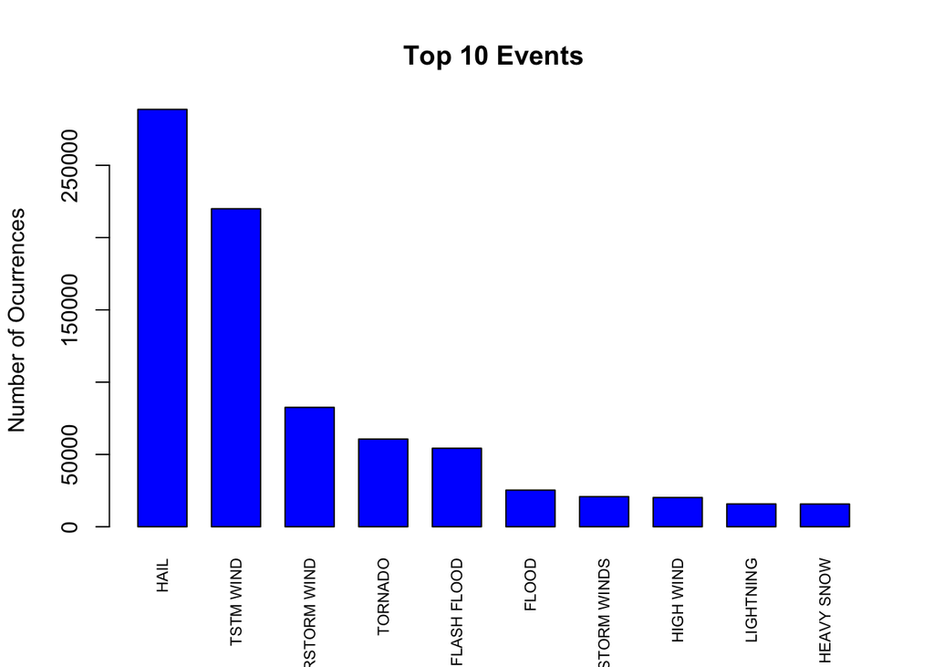

```r
barplot(total_bytype$Count,
        names.arg = total_bytype$EVTYPE,
        space=0.5,
        axes=TRUE,
        axisnames=TRUE,
         cex.names = 0.7,
        las=3,
        main = "Top 10 Events", col = "blue",
        ylab = "Number of Ocurrences")
```

This plots show the top 10 events most healthy harmful in the USA.

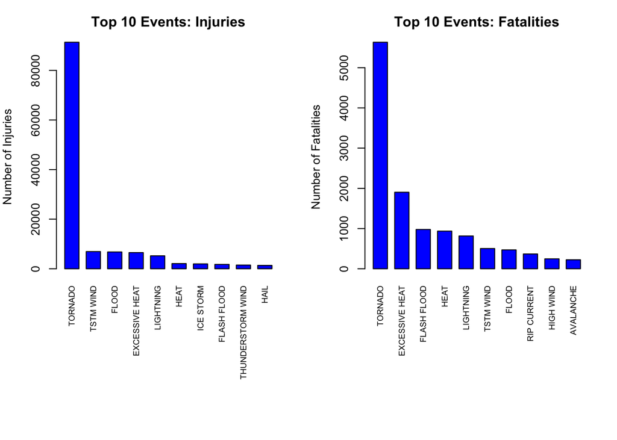

```r
par(mfrow=c(1,2), mar = c(12, 4, 3, 2), mgp = c(3, 1, 0), cex = 0.8)
barplot(injuries_bytype$INJURIES,
        names.arg = injuries_bytype$EVTYPE,
        space=0.5,
        axes=TRUE,
        axisnames=TRUE,
         cex.names = 0.7,
        las=3,
        main = "Top 10 Events: Injuries", col = "blue",
        ylab = "Number of Injuries")
barplot(fatalities_bytype$FATALITIES,
        names.arg = fatalities_bytype$EVTYPE,
        space=0.5,
        axes=TRUE,
        axisnames=TRUE,
         cex.names = 0.7,
        las=3,
        main = "Top 10 Events: Fatalities", col = "blue",
        ylab = "Number of Fatalities")
```

This plots show the top 10 most economic harmful events

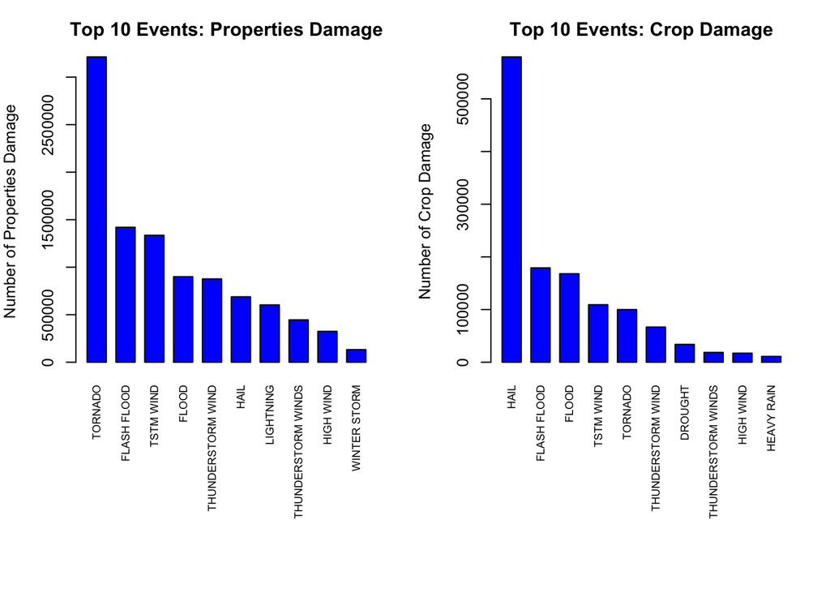

```r
options(scipen = 1)
par(mfrow=c(1,2), mar = c(12, 4, 3, 2), mgp = c(3, 1, 0), cex = 0.8)
barplot(properties_bytype$PROPDMG,
        names.arg = properties_bytype$EVTYPE,
        space=0.5,
        axes=TRUE,
        axisnames=TRUE,
         cex.names = 0.7,
        las=3,
        main = "Top 10 Events: Properties Damage", col = "blue",
        ylab = "Number of Properties Damage")
barplot(crop_bytype$CROPDMG,
        names.arg = crop_bytype$EVTYPE,
        space=0.5,
        axes=TRUE,
        axisnames=TRUE,
         cex.names = 0.7,
        las=3,
        main = "Top 10 Events: Crop Damage", col = "blue",
        ylab = "Number of Crop Damage")
```

As You can see in the previous plots and tables, the Tornado is the most harmful event, also is the one that causes most properties damage. But, the one that causes the most crops damage is the Hail.